# Supplement to *‘The effectiveness of note taking through exposure to L2 input: A new look at Jin and Webb (2023)’*

© Authors

March, 2024

# 1 Raw data and initial analyses

The execution of these initial analyses may be time consuming. Unless otherwise needed, we suggest that readers instead run the analyses in the next section which in reality use the results of these initial analyses (*Click on `Code` on the bottom right for details in each section*).

```r
# We use Software introduced by Norouzian & Bui (2023)
source("https://t.ly/TVmIg")

# We also use the following R package for choosing the best candidate model:
library(bbmle)

# Raw coding sheet with merged first row and lots of empty cells
dat <- read.csv("https://t.ly/i5aYY", na=c(NA,"","NA","NULL"))

# Remove the merged first row but use the first row to rename the column names
dat2 <- setNames(dat[-1,], dat[1,])

# Remove any accidental spaces or empty rows or columns
dat3 <- full_clean(dat2)

# Make sure each column's data type is correctly recorded
dat4 <- type.convert(dat3, as.is=TRUE)

# Compute effect sizes
dat5 <- escalc("SMD", m1i = mT, m2i = mC, sd1i = sdT, sd2i = sdC,
               n1i = nT, n2i = nC, data = dat4, var.names = c("g", "v_g"))


# Adjust for assignment by intact classes
dat6 <- group_by(dat5, study) %>%

  mutate(

    g2 = ifelse(assign_type=="class", g_cluster(g, n_class, Nt, Nc), g),

    v_g2 = ifelse(assign_type=="class", g_vi_cluster(g, n_class, Nt, Nc), v_g),

    SE_egger =  sqrt((nT + nC) / (nT * nC)),

    time = recode(time, "pretest" = "baseline")

  ) %>% ungroup() %>%

  mutate(effect = row_number())


# How many effects and studies:
dat6 %>%
  group_by(study) %>%
  summarise(n_gi = n()) %>%
  summarise(
    `No. of Studies` = n(),
    `No. of Effects` = sum(n_gi)
  ) %>% ungroup()


# What is the distribution of effects:
ggplot(dat6) + aes(g2) + geom_density()

# Quite skewed to the right, looks like we have some large effects
# even though we have only 57 effects from 27 studies

# What are the two largest effects?
two_largest <- tail(sort(dat6$g2),2)
# [1]  6.89757 10.45655 insanely large, over 10X larger than
# than mean(dat7$g2) which is 0.9!


# These two large effects also exceed 3*SD from the mean (Lipsey & Wilson, 2001)
two_largest > with(dat6, c(`3SDfromMean`= mean(g2)+3*sd(g2)))


# Let's inspect the impact of these two extreme effects on a
# basic 3-level model

# Reintroduce naturally occurring dependence before removing 2 largest effects
Vs <- with(dat6, impute_covariance_matrix(v_g2, study, r=.5,
                                          subgroup = sample_id))


# 3-level Additive symmetry model
m1 = rma.mv(g2 ~ time + study_length+no_treat+true_experiment, Vs,
            random = ~1|study/effect, data = dat6,
            dfs = "contain")


# Removing 2 largest effect sizes to measure their impact on m1
dat7 <- filter(dat6, !g2 %in% two_largest)


# Reintroduce naturally occurring dependence AFTER removing 2 largest effects
Vs_af <- with(dat7, impute_covariance_matrix(v_g2, study, r=.5,
                                          subgroup = sample_id))


# m1 model before removing 2 largest effects
m_before <- m1

# m1 model AFTER removing 2 largest effects
m_after <- update(m_before, data=dat7, V=Vs_af)


(t_bf =type.convert( post_rma(m_before,~ time)$table, as.is=TRUE))
(t_af =type.convert( post_rma(m_after,~ time)$table, as.is=TRUE))

(t_bf_ci_widths = t_bf$Upper - t_bf$Lower)
(t_af_ci_widths = t_af$Upper - t_af$Lower)

# The %reduction in the width of CIs due to removing two outliers
paste0(round((t_bf_ci_widths - t_af_ci_widths)/t_bf_ci_widths*100),"%")
# [1] "52%" "46%" "56%"


# Vast improvement in precision (CIs narrower by up to 56%) due to removing two outliers!

# Continue to model selection without the two outlying effects using dat7
# Let's run 5 more models in addition to m_after and choose:


####################
# Model selection
####################

# 3-level Additive symmetry model
m1 <- m_after

# Estimation checks out, passes!
profile(m1)


# Homogeneous Auto-regressive model
m2 = rma.mv(g2 ~ time + study_length+no_treat+true_experiment, Vs_af,
            random = list(~time|study, ~1|effect), struct = "AR",
            data = dat7,
            dfs = "contain")

# Estimation checks out, passes!
profile(m2)

# Heterogeneous auto-regressive model
m3 = rma.mv(g2 ~ time + study_length+no_treat+true_experiment, Vs_af,
            random = list(~time|study, ~1|effect), struct="HAR",
            data = dat7,
            dfs = "contain")

# Estimation doesn't check out, exclude this model!
profile(m3)

# Heterogeneous compound symmetry model
m4 = rma.mv(g2 ~ time + study_length+no_treat+true_experiment, Vs_af,
            random = list(~time|study, ~1|effect), struct = "HCS",
            data = dat7,
            dfs = "contain")


# Estimation doesn't check out, exclude this model!
profile(m4)

# Homogeneous compound symmety model
m5 = rma.mv(g2 ~ time + study_length+no_treat+true_experiment, Vs_af,
            random = list(~time|study, ~1|effect), struct = "CS",
            data = dat7,
            dfs = "contain")

# Estimation doesn't check out, exclude this model!
profile(m5)


# 4-level Additive symmetry model
m6 = rma.mv(g2 ~ time + study_length+no_treat+true_experiment, Vs_af,
            random = ~1|study/time/effect, data = dat7,
            dfs = "contain")

# Estimation checks out, passes!
profile(m6)


# Run a weighted comparison between the above 'checked out' models:
AICctab(m1, m2, m6, weights=TRUE, base=TRUE)

# m1 wins!! We'll use a 3-level additive symmetry model.


# Q: Is this overall longitudinal model sensitive to the amount of naturally occurring dependence?

# Time effects:
p2 <- post_rma(m1, ~time)

# Sensitivity analysis:
sense_rma(p2, var_name = "v_g2")

# A: Not really except in the case of posttest2 effects which are excluded from interpretation due to their extremely limited number (see next part).

# How many studies and effects for each meta-analytic model do we have?
moderators <-  c(
            "time",
            "treat_grp",
            "outcome",
            "input_mode",
            "material_type",
            "note_option",
            "note_instruct",
            "prof",
            "script_distance",
            "region")


# A list of time and moderators interacting with time
LIST <- c("time", map(moderators[-1], c, "time"))


# Count # of studies and effects at each time
setNames(map(LIST, ~effect_count(dat7, study, !!!syms(.), show0=FALSE, arrange_by="time", na.rm=TRUE)), moderators)

# post-test2 effects (m=4) are from 3 studies! Exclude from interpretations.

########################################
# Model fitting after initial steps
########################################

#==============================================
# Fit all moderator models using a function

fit_model <- function(pred="none",
                      V = Vs_af, data = dat7,
                      method_vars = c("study_length","no_treat",
                                      "true_experiment")){

  overall <- pred=="none"

  time_case <- if(pred!="time")"* time" else " "

  form <- as.formula(paste("g2 ~", if(overall) "" else paste(paste(pred, time_case),"+"),
                           paste(setdiff(method_vars,pred),
                                 collapse = "+")))

  m <- rma.mv(form, V = V,
              random = ~1|study/effect, data = data,
              dfs = "contain")

  form_post_rma <- if(overall) ~1 else as.formula(paste("~",pred, time_case))

  ems <- post_rma(m, form_post_rma)

  con <- if(!overall) contrast_rma(ems, "pairwise") else NA

  form_plot <- if(overall) ~1 else as.formula(paste(if(pred=="time") "~" else paste(pred,"~"), "time"))


  legend_t <- if(!overall){
    if(pred=="time")"Time" else
      if(pred=="measure")"Measure Type" else
        if(pred=="test_type")"Test Type" else
          if(pred=="prof") "Proficiency" else
            if(pred=="study_setting") "Study Setting" else
              if(pred=="lang_context") "Language Context" else
                if(pred=="treat_grp") "Note-Taking Type" else
                  if(pred=="region") "Region" else
                    if(pred=="input_mode") "Input Mode" else
                      if(pred=="note_option") "Note-Taking Option" else
                        if(pred=="note_instruct") "Note-Taking Instruction" else
                          if(pred=="script_distance") "L1-L2 Orthographic Distance" else
                            if(pred=="age_group") "Age Group" else
                              if(pred=="material_type") "Material Type" else
                                str_to_title(pred)
  } else
  { "Overall Effect" }


  plot <- plot_rma(m, form_plot, xlab = if(!overall) "Time" else NULL, ylab="Effect Size (Hedges' g)") +
    labs(color = legend_t)

  list(model = m, ems = ems, contrast = con, plot = plot)
}

#==============================================

# Fit all moderator models:
out <- setNames(map(moderators, fit_model), moderators)

# Save them and share them with readers
saveRDS(out, "np.rds")
```

# 2 Display of data and post-model hypothesis testing

As noted above, this section uses the saved results of the previous section (no need to actually run the R code in the previous section, unless otherwise needed). Readers are encouraged to actually run the following R codes. Once again, *click on `Code` on the bottom right for details in each section*.

```r
# We use the software package introduced by Norouzian & Bui (2023)
source("https://t.ly/TVmIg")
```

```
##
##
## Norouzian, R., & Bui, G. (in press). Meta-analysis of Second Language Research with
## Complex Research Designs. Studies in Second Languages Acquisition.
```

```r
library(knitr)
library(flextable)
library(kableExtra)
library(rmarkdown)

opts_chunk$set(message = FALSE, warning=FALSE, fig.align="center")


# data after outlier removal from previous initial analyses
dat7 <- read.csv("https://t.ly/O_J1u")
```

# 3 Distribution Summary of Effect Sizes

```r
g <- dat7 %>%
  group_by(study) %>%
  summarise(n_gi = n()) %>%
  summarise(
    `No. of Studies` = n(),
    `No. of Effects` = sum(n_gi),
    `Min. Effects in Study` = min(n_gi),
    `Max. Effects in Study` = max(n_gi),
    `Median Effects in Study` = median(n_gi)
  ) %>% ungroup()


flextable(g) %>%
  autofit() %>% set_caption("Distribution Summary of Effect Sizes") %>% fontsize(size = 11, part = "all") %>%
  line_spacing(space = .6, part = "all")
```

Distribution Summary of Effect Sizes

| No. of Studies | No. of Effects | Min. Effects in Study | Max. Effects in Study | Median Effects in Study |
| --- | --- | --- | --- | --- |
| 27 | 55 | 1 | 6 | 2 |

# 4 Publication Bias

## 4.1 Funnel plot at study level

Figure 3 displays the studies’ individual effect size estimates aggregated at the study level. The dotted triangle indicates the boundaries for statistical significance on either side of the null effect (i.e., *no study-level effect in reality exists; 0*). As can be seen, there are six effect size estimates aggregated at the study level that are statistically significant in magnitude and positive in direction. This value constitutes ~22% percent of the total number of study-level aggregate effect sizes in our meta-analysis. Furthermore, half of these study-level aggregate effect sizes are from the *“Less Visible Literature”* (Hopewell, Clarke, & Mallett, 2005) including the largest of them. Arguably, such evidence does not seem to indicate a tendency for the note-taking literature to intentionally favor studies that, as a whole, have found positive and statistically significant effects from note-taking. Thus, this form of publication bias at the study-level seems less likely.

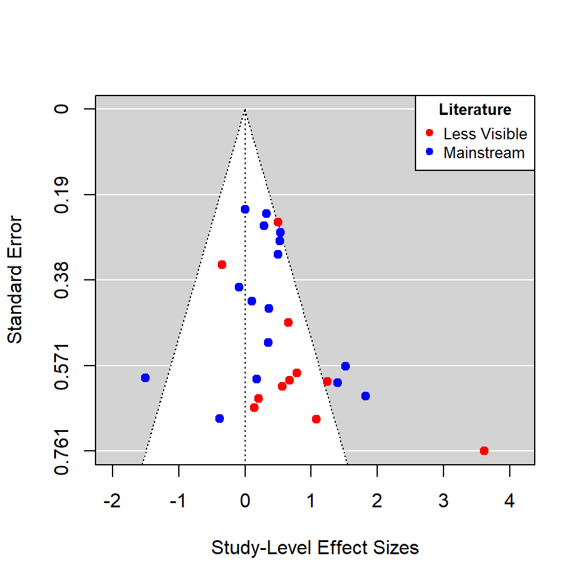

Figure 3. Contour-Enhanced Funnel Plot of Study-Level Effects

```r
Vs = with(dat7, impute_covariance_matrix(v_g2, study, r=.5,
                                        subgroup = sample_id))


#=== 3M publication bias detection:
# Magnitude of within-study correlations
rho <- 0.5

# Aggregate effects at Study level (level 3)
data_agg_study <-
  dat7 %>%
  escalc(data = ., yi = g2, vi = v_g2) %>%
  aggregate.escalc(cluster = study, rho = rho, weighted = FALSE)


with(data_agg_study,
     contour_funnel(x = g2,
                    vi = v_g2, sig = FALSE,
                    xlab = "Study-Level Effect Sizes",
                    col = ifelse(gray=="yes","red","blue"),
                    bg = ifelse(gray=="yes","red","blue")))


legend("topright", c("Less Visible","Mainstream"), title = "Literature", pch = 19,
       col = c("red","blue"), title.font = 2, cex = .8)
box()
```

```r
flextable(g) %>%
  autofit() %>% set_caption("Funnel plot at study level") %>% fontsize(size = 11, part = "all") %>%
  line_spacing(space = .6, part = "all")
```

Funnel plot at study level

| Total | Total(%) | Left | Left(%) | Right | Right(%) | Sig. |
| --- | --- | --- | --- | --- | --- | --- |
| 7 | 25.93 | 1 | 3.7 | 6 | 22.22 | 0.05 |

## 4.2 Funnel plot at effect size level

Figure 4 displays the studies’ individual effect size estimates. As before, the dotted triangle indicates the boundaries for statistical significance on either side of the null *effect* (i.e., *no individual effect in reality exists; 0*). As can be seen, there are seventeen effect size estimates that are statistically significant in magnitude and positive in direction. This value constitutes ~31% percent of the total number of effect sizes in our meta-analysis. On the other hand, there are two effect size estimates that are statistically significant in magnitude and *negative* in direction. This value constitutes ~3% percent of the total number of effect sizes in our meta-analysis. Furthermore, ~30% of these effect estimates are from the *“Less Visible Literature”* including the largest of them.

Arguably, the comparison at the effect size level could potentially suggest the possibility of *an imbalance* in the note-taking literature in favor of the positive and statistically significant effects. However, given the lack of such an imbalance at the study-level and presence of multiple positive and statistically significant effects in the less visible literature, the trend seen at the effect size level might indicate a somewhat natural process that is not, for the most part, impacted by the publication industry’s policies as to which studies should be published and which ones should not in the note-taking literature.

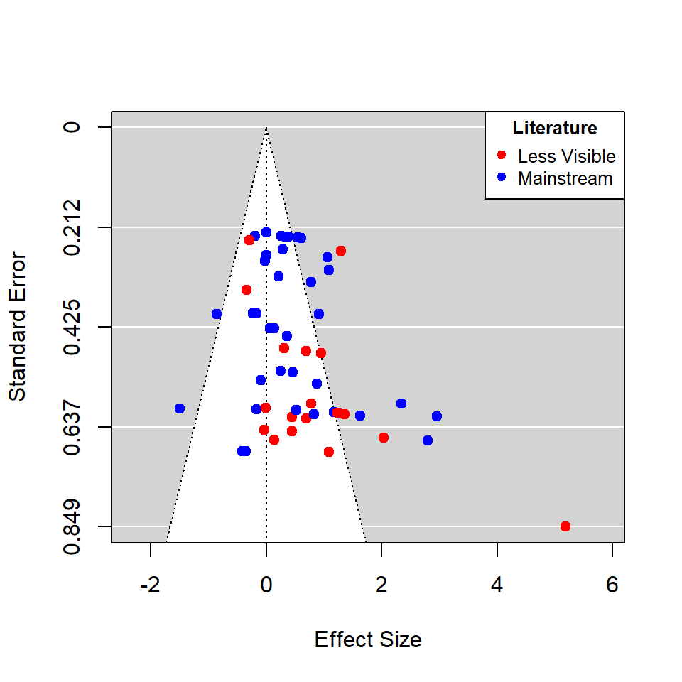

Figure 4. Contour-Enhanced Funnel Plot of Individual Effects

```r
with(dat7,
      contour_funnel(x = g2,
                     vi = v_g2, sig = FALSE,
                     col = ifelse(gray=="yes","red","blue"),
                     bg = ifelse(gray=="yes","red","blue")))

legend("topright", c("Less Visible","Mainstream"), title = "Literature", pch = 19,
       col = c("red","blue"), title.font = 2, cex = .8)
box()
```

```r
flextable(g) %>%
  autofit() %>% set_caption("Funnel plot at Effect Size level") %>% fontsize(size = 11, part = "all") %>%
  line_spacing(space = .6, part = "all")
```

Funnel plot at Effect Size level

| Total | Total(%) | Left | Left(%) | Right | Right(%) | Sig. |
| --- | --- | --- | --- | --- | --- | --- |
| 19 | 34.55 | 2 | 3.64 | 17 | 30.91 | 0.05 |

## 4.3 Egger’s test

We also conducted an Egger’s test (Egger, Smith, Schneider, & Minder, 1997) of funnel plot symmetry. Using this test, we examined the extent to which the standard error (i.e., precision) of the effect sizes collected from the note-taking literature related to the effect sizes’ magnitude. If such a relationship rises to a statistically significant level, that could suggest publication bias and asymmetry in the funnel plot of effect sizes.

In our case, given that the p-value for the Egger’s test was larger than 0.05, we concluded that our funnel plot is symmetric and the likelihood of publication bias in the collected sample of note-taking studies is small.

```r
# Eggers test:
ff = rma.mv(g2 ~ SE_egger, V = Vs,
            random = list(~1|study/effect), data = dat7,
            dfs = "contain")

g <- results_rma(ff, drop_rows = 3:7, drop_cols = 9:10)

flextable(dplyr::select(g, -Df)) %>%
  autofit() %>% set_caption("Egger's Test Results") %>% fontsize(size = 11, part = "all") %>%
  line_spacing(space = .6, part = "all")
```

Egger's Test Results

| Estimate | SE | t | p-value | Sig. | Lower | Upper |
| --- | --- | --- | --- | --- | --- | --- |
| 0.390 | 0.428 | 0.912 | 0.370 |  | -0.491 | 1.271 |
| 0.427 | 1.549 | 0.275 | 0.784 |  | -2.680 | 3.533 |

# 5 Results of analyses

```r
table_names <-
  c("Time",
    "Note-Taking Type",
    "Outcome",
    "Input Mode",
    "Material Type",
    "Optional Note-Taking",
    "Note-Taking Instruction",
    "Proficiency",
    "L1-L2 Orthographical Differences",
    "Region")


# Fitted moderator models stored from the previous section
results <- setNames(readRDS(url("https://t.ly/sPhtc")), table_names)


moderators_abb_names <-  c(
            "time",
            "treat_grp",
            "outcome",
            "input_mode",
            "material_type",
            "note_option",
            "note_instruct",
            "prof",
            "script_distance",
            "region")


# A list of time and moderators interacting with time
LIST <- c("time", map(moderators_abb_names[-1], c, "time"))


# Count # of studies and effects at each time
effect_no <- setNames(map(LIST, ~effect_count(dat7, study, !!!syms(.), show0=FALSE, na.rm=TRUE, arrange_by="time")), table_names)
```

```r
rs <- results

invisible(lapply(table_names, \(i){


  cat(paste0("\n\n## ", i, "\n"))


g <- rs[[i]]$ems


g3 <- rs[[i]]$plot

if(i!="Overall") print(g3)


print(kable(dplyr::select(cbind(g$table, dplyr::select(effect_no[[i]], `n study`, `n effect`)), -Df) %>% rename(K=`n study`, M=`n effect`),format = "simple", table.attr = "style='width:40%;'",
            caption = paste("3M results for",i,"categories")) %>%
  kable_styling(bootstrap_options = "bordered",
                full_width = TRUE, font_size = 9.5))

}))
```

## 5.1 Time

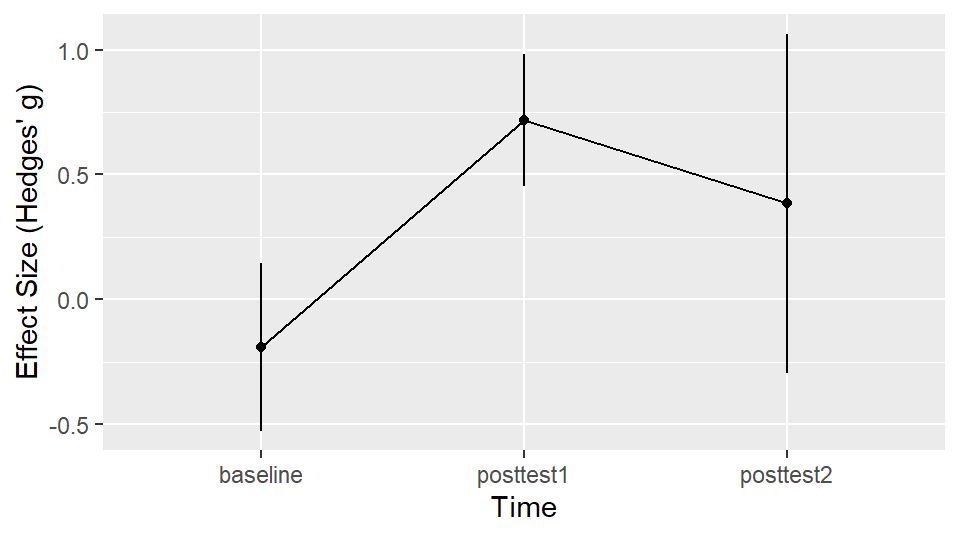

3M results for Time categories

| time | Mean | SE | Lower | Upper | t | p-value | Sig. | K | M |
| --- | --- | --- | --- | --- | --- | --- | --- | --- | --- |
| baseline | -0.191 | 0.159 | -0.526 | 0.144 | -1.200 | 0.246 |  | 16 | 18 |
| posttest1 | 0.719 | 0.126 | 0.455 | 0.982 | 5.723 | 0.000 | *** | 25 | 33 |
| posttest2 | 0.384 | 0.323 | -0.295 | 1.063 | 1.187 | 0.250 |  | 3 | 4 |

## 5.2 Note-Taking Type

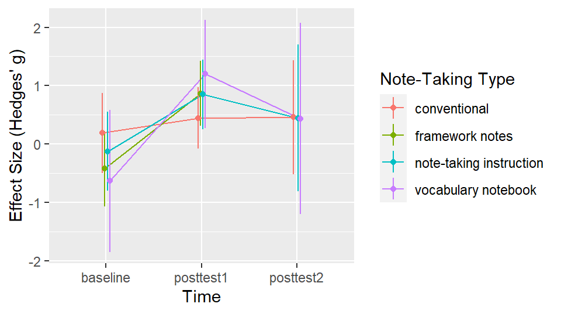

3M results for Note-Taking Type categories

|  | treat_grp | time | Mean | SE | Lower | Upper | t | p-value | Sig. | K | M |
| --- | --- | --- | --- | --- | --- | --- | --- | --- | --- | --- | --- |
| 1 | conventional | baseline | 0.187 | 0.308 | -0.500 | 0.874 | 0.606 | 0.558 |  | 3 | 4 |
| 2 | framework notes | baseline | -0.424 | 0.290 | -1.071 | 0.223 | -1.461 | 0.175 |  | 7 | 7 |
| 3 | note-taking instruction | baseline | -0.127 | 0.304 | -0.804 | 0.551 | -0.416 | 0.686 |  | 5 | 5 |
| 4 | vocabulary notebook | baseline | -0.635 | 0.545 | -1.850 | 0.580 | -1.165 | 0.271 |  | 1 | 2 |
| 5 | conventional | posttest1 | 0.446 | 0.235 | -0.077 | 0.969 | 1.900 | 0.087 | . | 7 | 12 |
| 6 | framework notes | posttest1 | 0.866 | 0.251 | 0.306 | 1.425 | 3.449 | 0.006 | ** | 9 | 9 |
| 7 | note-taking instruction | posttest1 | 0.851 | 0.267 | 0.256 | 1.446 | 3.185 | 0.010 | ** | 7 | 7 |
| 8 | vocabulary notebook | posttest1 | 1.199 | 0.416 | 0.271 | 2.126 | 2.879 | 0.016 | * | 3 | 5 |
| 9 | conventional | posttest2 | 0.457 | 0.440 | -0.524 | 1.438 | 1.038 | 0.324 |  | 1 | 2 |
| 11 | note-taking instruction | posttest2 | 0.444 | 0.564 | -0.813 | 1.701 | 0.786 | 0.450 |  | 1 | 1 |
| 12 | vocabulary notebook | posttest2 | 0.434 | 0.735 | -1.203 | 2.072 | 0.591 | 0.568 |  | 1 | 1 |

## 5.3 Outcome

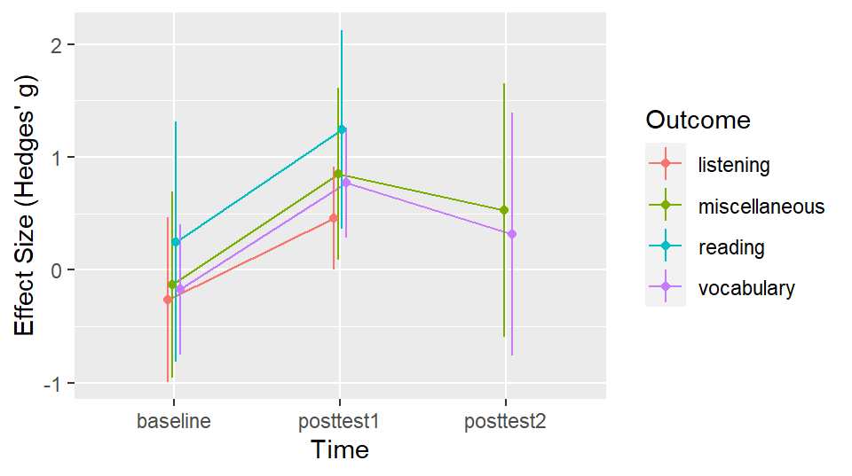

3M results for Outcome categories

|  | outcome | time | Mean | SE | Lower | Upper | t | p-value | Sig. | K | M |
| --- | --- | --- | --- | --- | --- | --- | --- | --- | --- | --- | --- |
| 1 | listening | baseline | -0.264 | 0.331 | -0.991 | 0.464 | -0.798 | 0.442 |  | 6 | 6 |
| 2 | miscellaneous | baseline | -0.130 | 0.376 | -0.956 | 0.697 | -0.345 | 0.736 |  | 3 | 3 |
| 3 | reading | baseline | 0.249 | 0.483 | -0.815 | 1.313 | 0.515 | 0.616 |  | 3 | 3 |
| 4 | vocabulary | baseline | -0.172 | 0.263 | -0.751 | 0.406 | -0.657 | 0.525 |  | 5 | 6 |
| 5 | listening | posttest1 | 0.456 | 0.208 | -0.001 | 0.914 | 2.196 | 0.050 | . | 9 | 14 |
| 6 | miscellaneous | posttest1 | 0.852 | 0.347 | 0.088 | 1.616 | 2.455 | 0.032 | * | 4 | 4 |
| 7 | reading | posttest1 | 1.244 | 0.399 | 0.366 | 2.123 | 3.119 | 0.010 | ** | 5 | 5 |
| 8 | vocabulary | posttest1 | 0.774 | 0.221 | 0.287 | 1.261 | 3.500 | 0.005 | ** | 8 | 10 |
| 10 | miscellaneous | posttest2 | 0.527 | 0.510 | -0.594 | 1.649 | 1.035 | 0.323 |  | 1 | 1 |
| 12 | vocabulary | posttest2 | 0.316 | 0.490 | -0.762 | 1.393 | 0.644 | 0.533 |  | 3 | 3 |

## 5.4 Input Mode

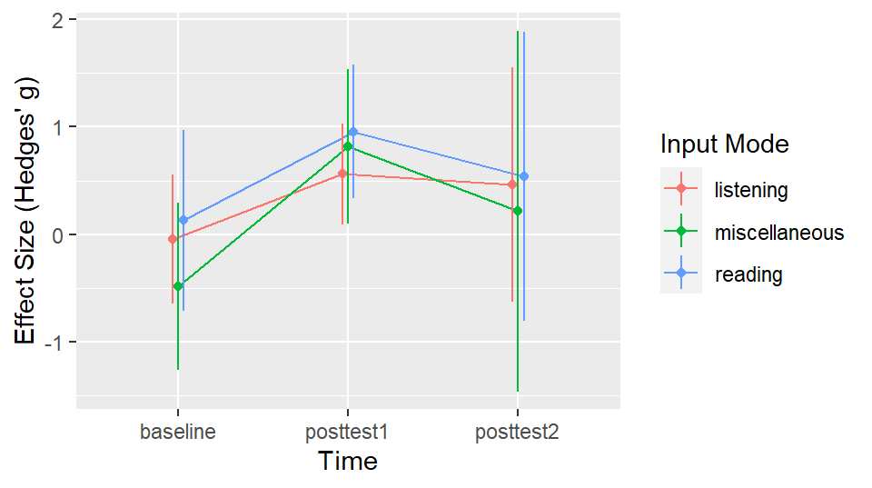

3M results for Input Mode categories

| input_mode | time | Mean | SE | Lower | Upper | t | p-value | Sig. | K | M |
| --- | --- | --- | --- | --- | --- | --- | --- | --- | --- | --- |
| listening | baseline | -0.044 | 0.276 | -0.646 | 0.558 | -0.159 | 0.876 |  | 7 | 8 |
| miscellaneous | baseline | -0.481 | 0.357 | -1.258 | 0.297 | -1.347 | 0.203 |  | 5 | 6 |
| reading | baseline | 0.129 | 0.388 | -0.716 | 0.973 | 0.332 | 0.746 |  | 4 | 4 |
| listening | posttest1 | 0.560 | 0.217 | 0.087 | 1.033 | 2.581 | 0.024 | * | 10 | 16 |
| miscellaneous | posttest1 | 0.818 | 0.330 | 0.099 | 1.537 | 2.479 | 0.029 | * | 7 | 9 |
| reading | posttest1 | 0.954 | 0.285 | 0.334 | 1.575 | 3.351 | 0.006 | ** | 8 | 8 |
| listening | posttest2 | 0.462 | 0.499 | -0.625 | 1.549 | 0.926 | 0.373 |  | 1 | 2 |
| miscellaneous | posttest2 | 0.215 | 0.769 | -1.461 | 1.891 | 0.280 | 0.785 |  | 1 | 1 |
| reading | posttest2 | 0.536 | 0.618 | -0.809 | 1.882 | 0.868 | 0.402 |  | 1 | 1 |

## 5.5 Material Type

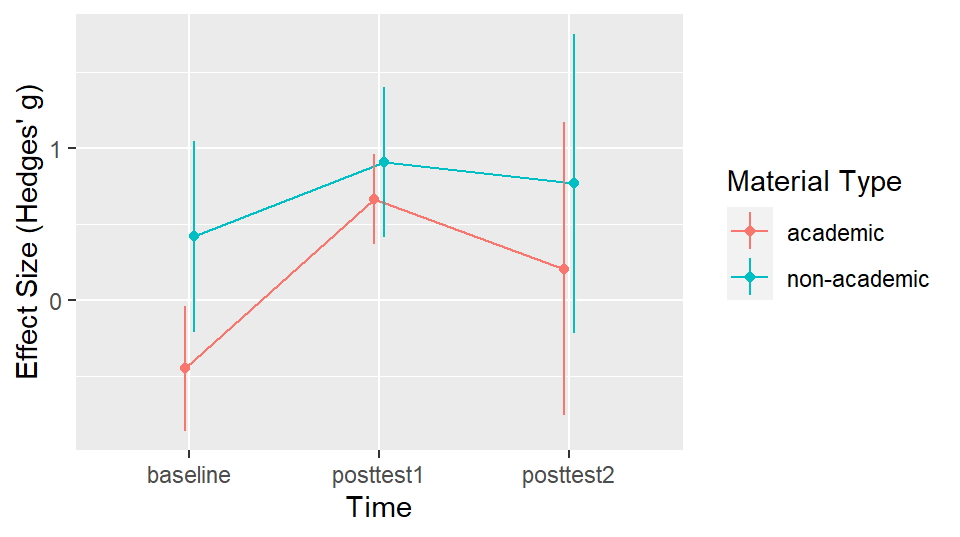

3M results for Material Type categories

| material_type | time | Mean | SE | Lower | Upper | t | p-value | Sig. | K | M |
| --- | --- | --- | --- | --- | --- | --- | --- | --- | --- | --- |
| academic | baseline | -0.451 | 0.192 | -0.860 | -0.042 | -2.349 | 0.033 | * | 13 | 14 |
| non-academic | baseline | 0.418 | 0.295 | -0.212 | 1.048 | 1.415 | 0.178 |  | 3 | 4 |
| academic | posttest1 | 0.666 | 0.139 | 0.370 | 0.961 | 4.797 | 0.000 | *** | 19 | 25 |
| non-academic | posttest1 | 0.909 | 0.232 | 0.413 | 1.404 | 3.910 | 0.001 | ** | 6 | 8 |
| academic | posttest2 | 0.205 | 0.452 | -0.758 | 1.168 | 0.453 | 0.657 |  | 2 | 2 |
| non-academic | posttest2 | 0.767 | 0.461 | -0.216 | 1.750 | 1.663 | 0.117 |  | 1 | 2 |

## 5.6 Optional Note-Taking

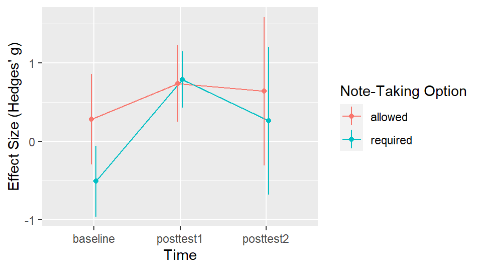

3M results for Optional Note-Taking categories

| note_option | time | Mean | SE | Lower | Upper | t | p-value | Sig. | K | M |
| --- | --- | --- | --- | --- | --- | --- | --- | --- | --- | --- |
| allowed | baseline | 0.283 | 0.268 | -0.292 | 0.859 | 1.055 | 0.309 |  | 5 | 6 |
| required | baseline | -0.506 | 0.210 | -0.956 | -0.055 | -2.409 | 0.030 | * | 10 | 11 |
| allowed | posttest1 | 0.737 | 0.228 | 0.249 | 1.226 | 3.236 | 0.006 | ** | 8 | 11 |
| required | posttest1 | 0.789 | 0.166 | 0.433 | 1.145 | 4.757 | 0.000 | *** | 16 | 20 |
| allowed | posttest2 | 0.639 | 0.440 | -0.304 | 1.583 | 1.454 | 0.168 |  | 1 | 2 |
| required | posttest2 | 0.263 | 0.440 | -0.679 | 1.206 | 0.599 | 0.559 |  | 2 | 2 |

## 5.7 Note-Taking Instruction

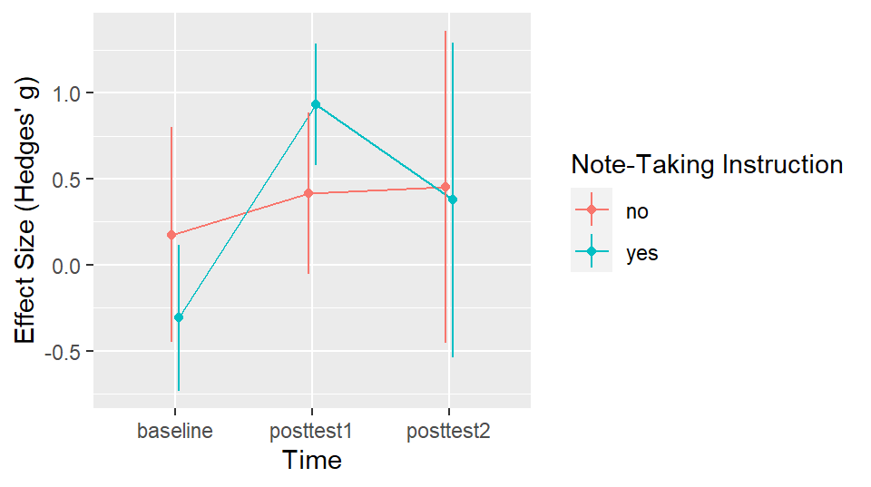

3M results for Note-Taking Instruction categories

| note_instruct | time | Mean | SE | Lower | Upper | t | p-value | Sig. | K | M |
| --- | --- | --- | --- | --- | --- | --- | --- | --- | --- | --- |
| no | baseline | 0.175 | 0.294 | -0.451 | 0.800 | 0.595 | 0.561 |  | 3 | 4 |
| yes | baseline | -0.310 | 0.198 | -0.733 | 0.113 | -1.561 | 0.139 |  | 13 | 14 |
| no | posttest1 | 0.417 | 0.221 | -0.054 | 0.888 | 1.888 | 0.079 | . | 7 | 12 |
| yes | posttest1 | 0.931 | 0.166 | 0.577 | 1.285 | 5.612 | 0.000 | *** | 19 | 21 |
| no | posttest2 | 0.452 | 0.426 | -0.457 | 1.361 | 1.060 | 0.306 |  | 1 | 2 |
| yes | posttest2 | 0.377 | 0.430 | -0.540 | 1.293 | 0.876 | 0.395 |  | 2 | 2 |

## 5.8 Proficiency

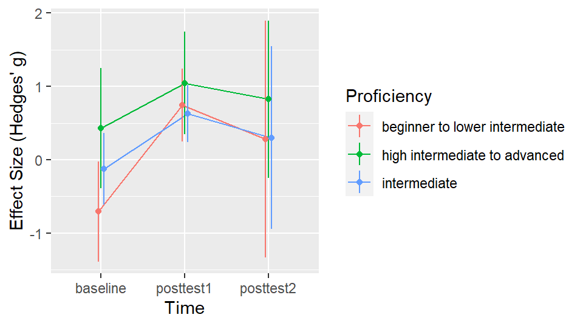

3M results for Proficiency categories

| prof | time | Mean | SE | Lower | Upper | t | p-value | Sig. | K | M |
| --- | --- | --- | --- | --- | --- | --- | --- | --- | --- | --- |
| beginner to lower intermediate | baseline | -0.707 | 0.312 | -1.386 | -0.027 | -2.267 | 0.043 | * | 3 | 4 |
| high intermediate to advanced | baseline | 0.431 | 0.375 | -0.385 | 1.248 | 1.151 | 0.272 |  | 2 | 3 |
| intermediate | baseline | -0.127 | 0.224 | -0.616 | 0.361 | -0.567 | 0.581 |  | 11 | 11 |
| beginner to lower intermediate | posttest1 | 0.744 | 0.229 | 0.246 | 1.242 | 3.253 | 0.007 | ** | 7 | 9 |
| high intermediate to advanced | posttest1 | 1.046 | 0.320 | 0.349 | 1.743 | 3.268 | 0.007 | ** | 4 | 5 |
| intermediate | posttest1 | 0.631 | 0.180 | 0.239 | 1.023 | 3.505 | 0.004 | ** | 14 | 19 |
| beginner to lower intermediate | posttest2 | 0.284 | 0.740 | -1.328 | 1.896 | 0.384 | 0.708 |  | 1 | 1 |
| high intermediate to advanced | posttest2 | 0.826 | 0.491 | -0.245 | 1.896 | 1.680 | 0.119 |  | 1 | 2 |
| intermediate | posttest2 | 0.302 | 0.573 | -0.947 | 1.550 | 0.527 | 0.608 |  | 1 | 1 |

## 5.9 L1-L2 Orthographical Differences

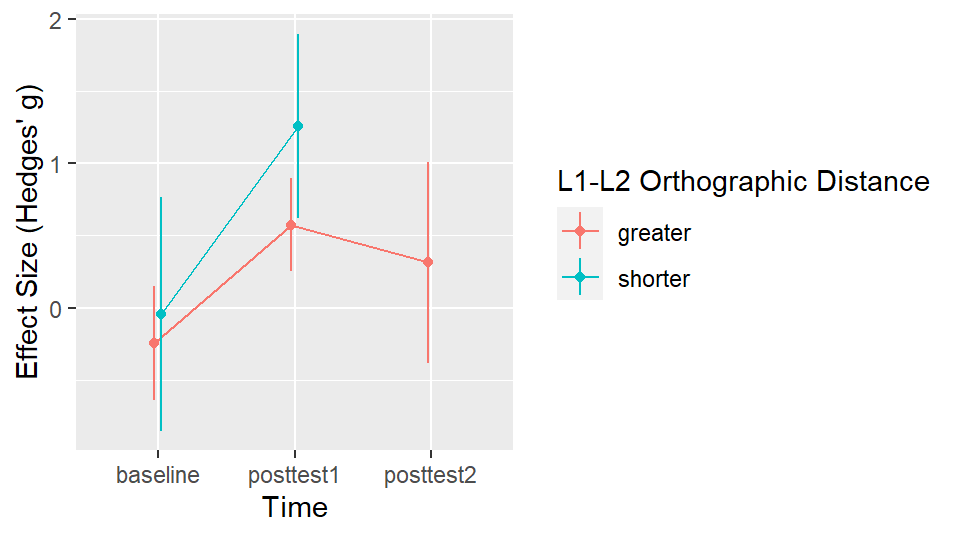

3M results for L1-L2 Orthographical Differences categories

| script_distance | time | Mean | SE | Lower | Upper | t | p-value | Sig. | K | M |
| --- | --- | --- | --- | --- | --- | --- | --- | --- | --- | --- |
| greater | baseline | -0.244 | 0.186 | -0.639 | 0.151 | -1.310 | 0.209 |  | 13 | 14 |
| shorter | baseline | -0.043 | 0.382 | -0.852 | 0.766 | -0.113 | 0.911 |  | 3 | 4 |
| greater | posttest1 | 0.573 | 0.152 | 0.252 | 0.895 | 3.778 | 0.002 | ** | 20 | 26 |
| shorter | posttest1 | 1.258 | 0.301 | 0.619 | 1.896 | 4.175 | 0.001 | *** | 5 | 7 |
| greater | posttest2 | 0.314 | 0.329 | -0.383 | 1.011 | 0.956 | 0.353 |  | 3 | 4 |

## 5.10 Region

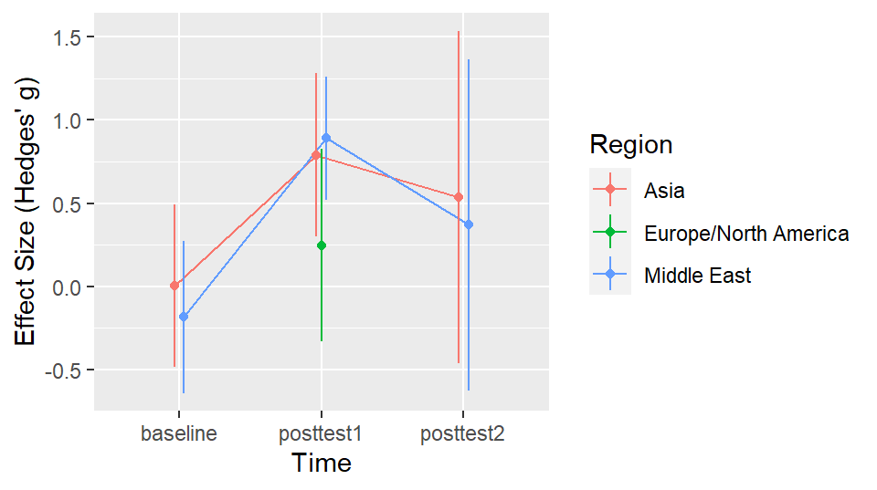

3M results for Region categories

|  | region | time | Mean | SE | Lower | Upper | t | p-value | Sig. | K | M |
| --- | --- | --- | --- | --- | --- | --- | --- | --- | --- | --- | --- |
| 1 | Asia | baseline | 0.005 | 0.227 | -0.482 | 0.492 | 0.021 | 0.983 |  | 6 | 7 |
| 3 | Middle East | baseline | -0.183 | 0.214 | -0.641 | 0.275 | -0.858 | 0.405 |  | 10 | 11 |
| 4 | Asia | posttest1 | 0.790 | 0.229 | 0.299 | 1.281 | 3.451 | 0.004 | ** | 6 | 7 |
| 5 | Europe/North America | posttest1 | 0.247 | 0.269 | -0.330 | 0.824 | 0.919 | 0.373 |  | 4 | 8 |
| 6 | Middle East | posttest1 | 0.890 | 0.172 | 0.521 | 1.259 | 5.178 | 0.000 | *** | 15 | 18 |
| 7 | Asia | posttest2 | 0.535 | 0.466 | -0.464 | 1.535 | 1.148 | 0.270 |  | 1 | 2 |
| 9 | Middle East | posttest2 | 0.369 | 0.463 | -0.625 | 1.362 | 0.797 | 0.439 |  | 2 | 2 |

# 6 Individual Gains (overall and for note-taking types)

## 6.1 overall learning gains over time in effect size

```r
## The Time model stored from the previous section is like this:

#p1 <- rma.mv(g2 ~ time +study_length+no_treat+true_experiment , Vs,
#            random = ~1|study/effect, data = dat7,
#            dfs = "contain")

#g <- post_rma(p1, ~ time)

# contrsat postest1 - baseline
gains <- contrast_rma(rs$Time$ems, c(2,-1), auto_name = TRUE)

flextable(dplyr::select(gains$table, -Df)) %>%
  autofit() %>% set_caption("3M Results for overall learning gains over Time") %>% fontsize(size = 11, part = "all") %>%
  line_spacing(space = .6, part = "all")
```

3M Results for overall learning gains over Time

| Contrast | Estimate | SE | Lower | Upper | t | p-value | Sig. |
| --- | --- | --- | --- | --- | --- | --- | --- |
| posttest1 - baseline | 0.910 | 0.171 | 0.551 | 1.268 | 5.331 | 0.000 | *** |

## 6.2 Overal gains in percentages

```r
# Turning gains to percentages
gain_prob <- prob_rma(gains, gain = TRUE, target_effect = .2)

flextable(gain_prob) %>%
  autofit() %>% set_caption("3M liklihoods for note-taking to benefit L2 learners") %>% fontsize(size = 11, part = "all") %>%
  line_spacing(space = .6, part = "all")
```

3M liklihoods for note-taking to benefit L2 learners

| Term | Target_Effect | Probability | Min | Max |
| --- | --- | --- | --- | --- |
| posttest1 - baseline | 0.2 or larger | 91.10% | 66.60% | 99.97% |

## 6.3 Gains for note-taking types in effect size

```r
## The treat_grp model stored from the previous section is like this:

# m_grp <- rma.mv(g2 ~ treat_grp*time + study_length+no_treat+true_experiment, Vs,
#                 random = ~1|study/effect, data = dat7,
#                 dfs = "contain")
#
# # post-test
# post_grp <- post_rma(m_grp, ~treat_grp*time)


gains <- contrast_rma(rs$`Note-Taking Type`$ems, brief = TRUE)


flextable(dplyr::select(gains$table, -Df)) %>%
  autofit() %>% set_caption("3M Results for learning gains for different   note-taking types over Time") %>% fontsize(size = 11, part = "all") %>%
  line_spacing(space = .6, part = "all")
```

3M Results for learning gains for different note-taking types over Time

| Contrast | Estimate | SE | Lower | Upper | t | p-value | Sig. |
| --- | --- | --- | --- | --- | --- | --- | --- |
| Gain1(conventional) | 0.259 | 0.263 | -0.327 | 0.844 | 0.985 | 0.348 |  |
| Gain2(conventional) | 0.270 | 0.419 | -0.663 | 1.203 | 0.644 | 0.534 |  |
| Gain1(framework notes) | 1.290 | 0.291 | 0.642 | 1.938 | 4.435 | 0.001 |  |
| Gain1(note-taking instruction) | 0.977 | 0.297 | 0.315 | 1.640 | 3.287 | 0.008 |  |
| Gain2(note-taking instruction) | 0.570 | 0.559 | -0.676 | 1.817 | 1.020 | 0.332 |  |
| Gain1(vocabulary notebook) | 1.834 | 0.480 | 0.763 | 2.904 | 3.817 | 0.003 |  |
| Gain2(vocabulary notebook) | 1.069 | 0.848 | -0.820 | 2.958 | 1.261 | 0.236 |  |

## 6.4 Gains for note-taking types in percentages

```r
# Turning gains to percentages
gain_prob <- prob_rma(gains, gain = TRUE, target_effect = .2)

flextable(gain_prob) %>%
  autofit() %>% set_caption("3M liklihoods for different note-taking types to benefit L2 learners") %>% fontsize(size = 11, part = "all") %>%
  line_spacing(space = .6, part = "all")
```

3M liklihoods for different note-taking types to benefit L2 learners

| Term | Target_Effect | Probability | Min | Max |
| --- | --- | --- | --- | --- |
| Gain1(conventional) | 0.2 or larger | 55.25% | 25.13% | 99.98% |
| Gain2(conventional) | 0.2 or larger | 56.23% | 13.61% | 100.00% |
| Gain1(framework notes) | 0.2 or larger | 99.27% | 71.30% | 100.00% |
| Gain1(note-taking instruction) | 0.2 or larger | 95.90% | 55.82% | 100.00% |
| Gain2(note-taking instruction) | 0.2 or larger | 79.62% | 13.26% | 100.00% |
| Gain1(vocabulary notebook) | 0.2 or larger | 99.99% | 76.31% | 100.00% |
| Gain2(vocabulary notebook) | 0.2 or larger | 97.41% | 9.72% | 100.00% |

## 6.5 Differences in gains from different note-taking types over time

```r
gain_dif <- contrast_rma(rs$`Note-Taking Type`$ems, gain_dif = TRUE, brief = TRUE, gain_dif_type = "same")

flextable(dplyr::select(gain_dif$table, -Df)) %>%
  autofit() %>% set_caption("3M Results for differences in learning gains from different note-taking types gains over Time") %>% fontsize(size = 11, part = "all") %>%
  line_spacing(space = .6, part = "all")
```

3M Results for differences in learning gains from different note-taking types gains over Time

| Contrast | Estimate | SE | Lower | Upper | t | p-value | Sig. |
| --- | --- | --- | --- | --- | --- | --- | --- |
| Gain1(conventional) - Gain1(framework notes) | -1.031 | 0.390 | -1.900 | -0.162 | -2.643 | 0.025 |  |
| Gain1(conventional) - Gain1(note-taking instruction) | -0.718 | 0.397 | -1.604 | 0.167 | -1.808 | 0.101 |  |
| Gain1(conventional) - Gain1(vocabulary notebook) | -1.575 | 0.549 | -2.797 | -0.352 | -2.871 | 0.017 |  |
| Gain2(conventional) - Gain2(note-taking instruction) | -0.300 | 0.700 | -1.859 | 1.258 | -0.429 | 0.677 |  |
| Gain2(conventional) - Gain2(vocabulary notebook) | -0.800 | 0.945 | -2.906 | 1.306 | -0.846 | 0.417 |  |
| Gain1(framework notes) - Gain1(note-taking instruction) | 0.313 | 0.415 | -0.611 | 1.236 | 0.754 | 0.468 |  |
| Gain1(framework notes) - Gain1(vocabulary notebook) | -0.544 | 0.556 | -1.783 | 0.696 | -0.978 | 0.351 |  |
| Gain1(note-taking instruction) - Gain1(vocabulary notebook) | -0.856 | 0.562 | -2.108 | 0.395 | -1.525 | 0.158 |  |
| Gain2(note-taking instruction) - Gain2(vocabulary notebook) | -0.499 | 1.025 | -2.782 | 1.784 | -0.487 | 0.637 |  |